# Risk Factor Analysis

## Outcome Variable

**Outcome Variable:** wast_rec90d

## Predictor Variables

**Intervention Variable:** nhh

**Adjustment Set:**

- arm
- W_mage
- meducyrs
- feducyrs
- W_mhtcm
- W_mwtkg
- W_mbmi
- W_nrooms
- cleanck
- impfloor
- impsan
- safeh20
- delta_W_mage
- delta_meducyrs
- delta_feducyrs
- delta_W_mhtcm
- delta_W_mwtkg
- delta_W_mbmi
- delta_W_nrooms
- delta_cleanck
- delta_impfloor
- delta_impsan
- delta_safeh20

## Stratifying Variables

The analysis was stratified on these variable(s):

- agecat
- studyid
- country

## Data Summary

| agecat | studyid | country | nhh | wast_rec90d | n_cell | n |
| --- | --- | --- | --- | --- | --- | --- |
| 0-24 months | ki1000108-IRC | INDIA | 3 or less | 0 | 17 | 395 |
| 0-24 months | ki1000108-IRC | INDIA | 3 or less | 1 | 32 | 395 |
| 0-24 months | ki1000108-IRC | INDIA | 4-5 | 0 | 61 | 395 |
| 0-24 months | ki1000108-IRC | INDIA | 4-5 | 1 | 75 | 395 |
| 0-24 months | ki1000108-IRC | INDIA | 6-7 | 0 | 47 | 395 |
| 0-24 months | ki1000108-IRC | INDIA | 6-7 | 1 | 60 | 395 |
| 0-24 months | ki1000108-IRC | INDIA | 8+ | 0 | 37 | 395 |
| 0-24 months | ki1000108-IRC | INDIA | 8+ | 1 | 66 | 395 |
| 0-24 months | ki1000304b-SAS-FoodSuppl | INDIA | 3 or less | 0 | 17 | 234 |
| 0-24 months | ki1000304b-SAS-FoodSuppl | INDIA | 3 or less | 1 | 1 | 234 |
| 0-24 months | ki1000304b-SAS-FoodSuppl | INDIA | 4-5 | 0 | 96 | 234 |
| 0-24 months | ki1000304b-SAS-FoodSuppl | INDIA | 4-5 | 1 | 3 | 234 |
| 0-24 months | ki1000304b-SAS-FoodSuppl | INDIA | 6-7 | 0 | 69 | 234 |
| 0-24 months | ki1000304b-SAS-FoodSuppl | INDIA | 6-7 | 1 | 6 | 234 |
| 0-24 months | ki1000304b-SAS-FoodSuppl | INDIA | 8+ | 0 | 39 | 234 |
| 0-24 months | ki1000304b-SAS-FoodSuppl | INDIA | 8+ | 1 | 3 | 234 |
| 0-24 months | ki1017093-NIH-Birth | BANGLADESH | 3 or less | 0 | 39 | 421 |
| 0-24 months | ki1017093-NIH-Birth | BANGLADESH | 3 or less | 1 | 40 | 421 |
| 0-24 months | ki1017093-NIH-Birth | BANGLADESH | 4-5 | 0 | 88 | 421 |
| 0-24 months | ki1017093-NIH-Birth | BANGLADESH | 4-5 | 1 | 91 | 421 |
| 0-24 months | ki1017093-NIH-Birth | BANGLADESH | 6-7 | 0 | 45 | 421 |
| 0-24 months | ki1017093-NIH-Birth | BANGLADESH | 6-7 | 1 | 55 | 421 |
| 0-24 months | ki1017093-NIH-Birth | BANGLADESH | 8+ | 0 | 30 | 421 |
| 0-24 months | ki1017093-NIH-Birth | BANGLADESH | 8+ | 1 | 33 | 421 |
| 0-24 months | ki1017093b-PROVIDE | BANGLADESH | 3 or less | 0 | 20 | 307 |
| 0-24 months | ki1017093b-PROVIDE | BANGLADESH | 3 or less | 1 | 27 | 307 |
| 0-24 months | ki1017093b-PROVIDE | BANGLADESH | 4-5 | 0 | 54 | 307 |
| 0-24 months | ki1017093b-PROVIDE | BANGLADESH | 4-5 | 1 | 87 | 307 |
| 0-24 months | ki1017093b-PROVIDE | BANGLADESH | 6-7 | 0 | 36 | 307 |
| 0-24 months | ki1017093b-PROVIDE | BANGLADESH | 6-7 | 1 | 39 | 307 |

[output cut: 114 more lines]

The following strata were considered:

- agecat: 0-24 months, studyid: ki1000108-IRC, country: INDIA
- agecat: 0-24 months, studyid: ki1000304b-SAS-FoodSuppl, country: INDIA
- agecat: 0-24 months, studyid: ki1017093-NIH-Birth, country: BANGLADESH
- agecat: 0-24 months, studyid: ki1017093b-PROVIDE, country: BANGLADESH
- agecat: 0-24 months, studyid: ki1017093c-NIH-Crypto, country: BANGLADESH
- agecat: 0-24 months, studyid: ki1148112-LCNI-5, country: MALAWI
- agecat: 0-6 months, studyid: ki1000108-IRC, country: INDIA
- agecat: 0-6 months, studyid: ki1000304b-SAS-FoodSuppl, country: INDIA
- agecat: 0-6 months, studyid: ki1017093-NIH-Birth, country: BANGLADESH
- agecat: 0-6 months, studyid: ki1017093b-PROVIDE, country: BANGLADESH
- agecat: 0-6 months, studyid: ki1017093c-NIH-Crypto, country: BANGLADESH
- agecat: 0-6 months, studyid: ki1148112-LCNI-5, country: MALAWI
- agecat: 6-24 months, studyid: ki1000108-IRC, country: INDIA
- agecat: 6-24 months, studyid: ki1000304b-SAS-FoodSuppl, country: INDIA
- agecat: 6-24 months, studyid: ki1017093-NIH-Birth, country: BANGLADESH
- agecat: 6-24 months, studyid: ki1017093b-PROVIDE, country: BANGLADESH
- agecat: 6-24 months, studyid: ki1017093c-NIH-Crypto, country: BANGLADESH
- agecat: 6-24 months, studyid: ki1148112-LCNI-5, country: MALAWI

### Dropped Strata

Some strata were dropped due to rare outcomes:

- agecat: 0-24 months, studyid: ki1000304b-SAS-FoodSuppl, country: INDIA
- agecat: 0-24 months, studyid: ki1148112-LCNI-5, country: MALAWI
- agecat: 0-6 months, studyid: ki1000304b-SAS-FoodSuppl, country: INDIA
- agecat: 0-6 months, studyid: ki1017093c-NIH-Crypto, country: BANGLADESH
- agecat: 0-6 months, studyid: ki1148112-LCNI-5, country: MALAWI
- agecat: 6-24 months, studyid: ki1000304b-SAS-FoodSuppl, country: INDIA
- agecat: 6-24 months, studyid: ki1017093b-PROVIDE, country: BANGLADESH
- agecat: 6-24 months, studyid: ki1017093c-NIH-Crypto, country: BANGLADESH
- agecat: 6-24 months, studyid: ki1148112-LCNI-5, country: MALAWI

## Methods Detail

We’re interested in the causal parameters $E[Y_a]$ for all values of $a \in \mathcal{A}$. These parameters represent the mean outcome if, possibly contrary to fact, we intervened to set all units to have $A=a$. Under the randomization and positivity assumptions, these are identified by the statistical parameters $\psi_a=E_W[E_{Y|A,W}(Y|A=a,W)]$. In addition, we’re interested in the mean of $Y$, $E[Y]$ under no intervention (the observed mean). We will estimate these parameters by using SuperLearner to fit the relevant likelihood factors – $E_{Y|A,W}(Y|A=a,W)$ and $p(A=a|W)$, and then updating our likelihood fit using a joint TMLE.

For unadjusted analyses ($W=\{\}$), initial likelihoods were estimated using Lrnr_glm to estimate the simple $E(Y|A)$ and Lrnr_mean to estimate $p(A)$. For adjusted analyses, a small library containing Lrnr_glmnet, Lrnr_xgboost, and Lrnr_mean was used.

Having estimated these parameters, we will then use the delta method to estimate relative risks and attributable risks relative to a prespecified baseline level of $A$.

# Results Detail

## Results Plots

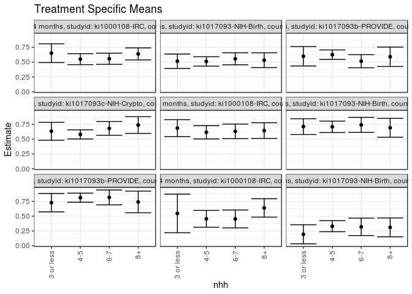

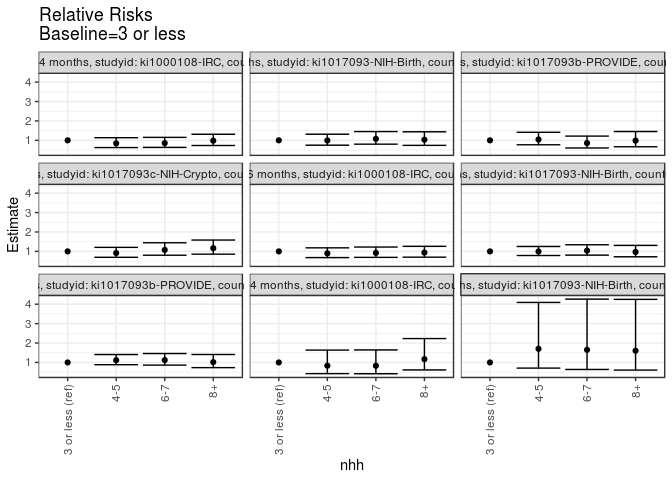

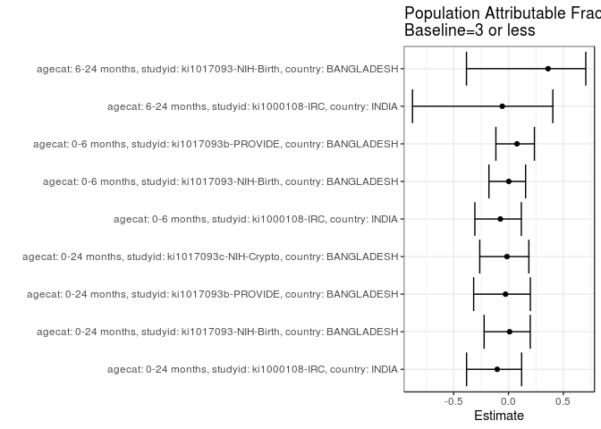

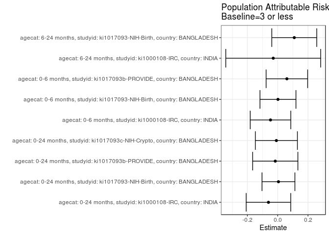

## Results Table

### Parameter: TSM

| agecat | studyid | country | intervention_level | baseline_level | estimate | ci_lower | ci_upper |
| --- | --- | --- | --- | --- | --- | --- | --- |
| 0-24 months | ki1000108-IRC | INDIA | 3 or less | NA | 0.6507943 | 0.4922611 | 0.8093275 |
| 0-24 months | ki1000108-IRC | INDIA | 4-5 | NA | 0.5498028 | 0.4572424 | 0.6423632 |
| 0-24 months | ki1000108-IRC | INDIA | 6-7 | NA | 0.5573562 | 0.4629420 | 0.6517703 |
| 0-24 months | ki1000108-IRC | INDIA | 8+ | NA | 0.6385876 | 0.5372267 | 0.7399485 |
| 0-24 months | ki1017093-NIH-Birth | BANGLADESH | 3 or less | NA | 0.5150220 | 0.3941970 | 0.6358469 |
| 0-24 months | ki1017093-NIH-Birth | BANGLADESH | 4-5 | NA | 0.5118897 | 0.4323949 | 0.5913845 |
| 0-24 months | ki1017093-NIH-Birth | BANGLADESH | 6-7 | NA | 0.5556430 | 0.4547801 | 0.6565058 |
| 0-24 months | ki1017093-NIH-Birth | BANGLADESH | 8+ | NA | 0.5320205 | 0.4072023 | 0.6568386 |
| 0-24 months | ki1017093b-PROVIDE | BANGLADESH | 3 or less | NA | 0.5990257 | 0.4348719 | 0.7631795 |
| 0-24 months | ki1017093b-PROVIDE | BANGLADESH | 4-5 | NA | 0.6259161 | 0.5458151 | 0.7060171 |
| 0-24 months | ki1017093b-PROVIDE | BANGLADESH | 6-7 | NA | 0.5151414 | 0.4049683 | 0.6253146 |
| 0-24 months | ki1017093b-PROVIDE | BANGLADESH | 8+ | NA | 0.5903555 | 0.4270474 | 0.7536636 |
| 0-24 months | ki1017093c-NIH-Crypto | BANGLADESH | 3 or less | NA | 0.6324256 | 0.4804503 | 0.7844008 |
| 0-24 months | ki1017093c-NIH-Crypto | BANGLADESH | 4-5 | NA | 0.5795931 | 0.5022494 | 0.6569368 |
| 0-24 months | ki1017093c-NIH-Crypto | BANGLADESH | 6-7 | NA | 0.6809444 | 0.5651821 | 0.7967068 |
| 0-24 months | ki1017093c-NIH-Crypto | BANGLADESH | 8+ | NA | 0.7374575 | 0.5961333 | 0.8787817 |
| 0-6 months | ki1000108-IRC | INDIA | 3 or less | NA | 0.6849028 | 0.5421600 | 0.8276457 |
| 0-6 months | ki1000108-IRC | INDIA | 4-5 | NA | 0.6148585 | 0.5029759 | 0.7267412 |
| 0-6 months | ki1000108-IRC | INDIA | 6-7 | NA | 0.6310148 | 0.5080900 | 0.7539395 |
| 0-6 months | ki1000108-IRC | INDIA | 8+ | NA | 0.6439607 | 0.5115745 | 0.7763468 |
| 0-6 months | ki1017093-NIH-Birth | BANGLADESH | 3 or less | NA | 0.7111482 | 0.5781556 | 0.8441407 |
| 0-6 months | ki1017093-NIH-Birth | BANGLADESH | 4-5 | NA | 0.7074945 | 0.6106276 | 0.8043614 |
| 0-6 months | ki1017093-NIH-Birth | BANGLADESH | 6-7 | NA | 0.7403076 | 0.6133526 | 0.8672626 |
| 0-6 months | ki1017093-NIH-Birth | BANGLADESH | 8+ | NA | 0.6911899 | 0.5319115 | 0.8504684 |
| 0-6 months | ki1017093b-PROVIDE | BANGLADESH | 3 or less | NA | 0.7272727 | 0.5723745 | 0.8821709 |
| 0-6 months | ki1017093b-PROVIDE | BANGLADESH | 4-5 | NA | 0.8111111 | 0.7342291 | 0.8879931 |
| 0-6 months | ki1017093b-PROVIDE | BANGLADESH | 6-7 | NA | 0.8157895 | 0.6901446 | 0.9414344 |
| 0-6 months | ki1017093b-PROVIDE | BANGLADESH | 8+ | NA | 0.7391304 | 0.5561946 | 0.9220662 |
| 6-24 months | ki1000108-IRC | INDIA | 3 or less | NA | 0.5454545 | 0.2197802 | 0.8711289 |
| 6-24 months | ki1000108-IRC | INDIA | 4-5 | NA | 0.4545455 | 0.3122734 | 0.5968175 |
| 6-24 months | ki1000108-IRC | INDIA | 6-7 | NA | 0.4523810 | 0.3012030 | 0.6035589 |
| 6-24 months | ki1000108-IRC | INDIA | 8+ | NA | 0.6382979 | 0.4831935 | 0.7934023 |
| 6-24 months | ki1017093-NIH-Birth | BANGLADESH | 3 or less | NA | 0.1935484 | 0.0330016 | 0.3540952 |
| 6-24 months | ki1017093-NIH-Birth | BANGLADESH | 4-5 | NA | 0.3296703 | 0.2363549 | 0.4229858 |
| 6-24 months | ki1017093-NIH-Birth | BANGLADESH | 6-7 | NA | 0.3191489 | 0.1718814 | 0.4664164 |
| 6-24 months | ki1017093-NIH-Birth | BANGLADESH | 8+ | NA | 0.3103448 | 0.1515470 | 0.4691427 |

### Parameter: E(Y)

| agecat | studyid | country | intervention_level | baseline_level | estimate | ci_lower | ci_upper |
| --- | --- | --- | --- | --- | --- | --- | --- |
| 0-24 months | ki1000108-IRC | INDIA | NA | NA | 0.5898734 | 0.5376978 | 0.6420491 |
| 0-24 months | ki1017093-NIH-Birth | BANGLADESH | NA | NA | 0.5201900 | 0.4695846 | 0.5707955 |
| 0-24 months | ki1017093b-PROVIDE | BANGLADESH | NA | NA | 0.5830619 | 0.5262762 | 0.6398476 |
| 0-24 months | ki1017093c-NIH-Crypto | BANGLADESH | NA | NA | 0.6237942 | 0.5698223 | 0.6777662 |
| 0-6 months | ki1000108-IRC | INDIA | NA | NA | 0.6375000 | 0.5751450 | 0.6998550 |
| 0-6 months | ki1017093-NIH-Birth | BANGLADESH | NA | NA | 0.7130045 | 0.6535890 | 0.7724200 |
| 0-6 months | ki1017093b-PROVIDE | BANGLADESH | NA | NA | 0.7880435 | 0.7295878 | 0.8464992 |
| 6-24 months | ki1000108-IRC | INDIA | NA | NA | 0.5161290 | 0.4322562 | 0.6000019 |
| 6-24 months | ki1017093-NIH-Birth | BANGLADESH | NA | NA | 0.3030303 | 0.2377927 | 0.3682679 |

### Parameter: RR

| agecat | studyid | country | intervention_level | baseline_level | estimate | ci_lower | ci_upper |
| --- | --- | --- | --- | --- | --- | --- | --- |
| 0-24 months | ki1000108-IRC | INDIA | 3 or less | 3 or less | 1.0000000 | 1.0000000 | 1.000000 |
| 0-24 months | ki1000108-IRC | INDIA | 4-5 | 3 or less | 0.8448181 | 0.6281687 | 1.136188 |
| 0-24 months | ki1000108-IRC | INDIA | 6-7 | 3 or less | 0.8564245 | 0.6364726 | 1.152387 |
| 0-24 months | ki1000108-IRC | INDIA | 8+ | 3 or less | 0.9812434 | 0.7336378 | 1.312417 |
| 0-24 months | ki1017093-NIH-Birth | BANGLADESH | 3 or less | 3 or less | 1.0000000 | 1.0000000 | 1.000000 |
| 0-24 months | ki1017093-NIH-Birth | BANGLADESH | 4-5 | 3 or less | 0.9939182 | 0.7501834 | 1.316842 |
| 0-24 months | ki1017093-NIH-Birth | BANGLADESH | 6-7 | 3 or less | 1.0788724 | 0.8019787 | 1.451367 |
| 0-24 months | ki1017093-NIH-Birth | BANGLADESH | 8+ | 3 or less | 1.0330054 | 0.7408902 | 1.440295 |
| 0-24 months | ki1017093b-PROVIDE | BANGLADESH | 3 or less | 3 or less | 1.0000000 | 1.0000000 | 1.000000 |
| 0-24 months | ki1017093b-PROVIDE | BANGLADESH | 4-5 | 3 or less | 1.0448902 | 0.7721056 | 1.414049 |
| 0-24 months | ki1017093b-PROVIDE | BANGLADESH | 6-7 | 3 or less | 0.8599655 | 0.6067098 | 1.218936 |
| 0-24 months | ki1017093b-PROVIDE | BANGLADESH | 8+ | 3 or less | 0.9855262 | 0.6683140 | 1.453302 |
| 0-24 months | ki1017093c-NIH-Crypto | BANGLADESH | 3 or less | 3 or less | 1.0000000 | 1.0000000 | 1.000000 |
| 0-24 months | ki1017093c-NIH-Crypto | BANGLADESH | 4-5 | 3 or less | 0.9164605 | 0.6955420 | 1.207547 |
| 0-24 months | ki1017093c-NIH-Crypto | BANGLADESH | 6-7 | 3 or less | 1.0767187 | 0.8024261 | 1.444772 |
| 0-24 months | ki1017093c-NIH-Crypto | BANGLADESH | 8+ | 3 or less | 1.1660779 | 0.8573901 | 1.585903 |
| 0-6 months | ki1000108-IRC | INDIA | 3 or less | 3 or less | 1.0000000 | 1.0000000 | 1.000000 |
| 0-6 months | ki1000108-IRC | INDIA | 4-5 | 3 or less | 0.8977311 | 0.6807024 | 1.183955 |
| 0-6 months | ki1000108-IRC | INDIA | 6-7 | 3 or less | 0.9213201 | 0.6925977 | 1.225576 |
| 0-6 months | ki1000108-IRC | INDIA | 8+ | 3 or less | 0.9402220 | 0.7015383 | 1.260113 |
| 0-6 months | ki1017093-NIH-Birth | BANGLADESH | 3 or less | 3 or less | 1.0000000 | 1.0000000 | 1.000000 |
| 0-6 months | ki1017093-NIH-Birth | BANGLADESH | 4-5 | 3 or less | 0.9948623 | 0.7889967 | 1.254442 |
| 0-6 months | ki1017093-NIH-Birth | BANGLADESH | 6-7 | 3 or less | 1.0410034 | 0.8074016 | 1.342192 |
| 0-6 months | ki1017093-NIH-Birth | BANGLADESH | 8+ | 3 or less | 0.9719352 | 0.7220479 | 1.308304 |
| 0-6 months | ki1017093b-PROVIDE | BANGLADESH | 3 or less | 3 or less | 1.0000000 | 1.0000000 | 1.000000 |
| 0-6 months | ki1017093b-PROVIDE | BANGLADESH | 4-5 | 3 or less | 1.1152778 | 0.8833614 | 1.408081 |
| 0-6 months | ki1017093b-PROVIDE | BANGLADESH | 6-7 | 3 or less | 1.1217105 | 0.8624459 | 1.458914 |
| 0-6 months | ki1017093b-PROVIDE | BANGLADESH | 8+ | 3 or less | 1.0163043 | 0.7331876 | 1.408745 |
| 6-24 months | ki1000108-IRC | INDIA | 3 or less | 3 or less | 1.0000000 | 1.0000000 | 1.000000 |
| 6-24 months | ki1000108-IRC | INDIA | 4-5 | 3 or less | 0.8333333 | 0.4246670 | 1.635268 |
| 6-24 months | ki1000108-IRC | INDIA | 6-7 | 3 or less | 0.8293651 | 0.4183925 | 1.644022 |
| 6-24 months | ki1000108-IRC | INDIA | 8+ | 3 or less | 1.1702128 | 0.6142262 | 2.229468 |
| 6-24 months | ki1017093-NIH-Birth | BANGLADESH | 3 or less | 3 or less | 1.0000000 | 1.0000000 | 1.000000 |
| 6-24 months | ki1017093-NIH-Birth | BANGLADESH | 4-5 | 3 or less | 1.7032967 | 0.7092180 | 4.090730 |
| 6-24 months | ki1017093-NIH-Birth | BANGLADESH | 6-7 | 3 or less | 1.6489362 | 0.6381154 | 4.260970 |
| 6-24 months | ki1017093-NIH-Birth | BANGLADESH | 8+ | 3 or less | 1.6034483 | 0.6051792 | 4.248405 |

### Parameter: PAR

| agecat | studyid | country | intervention_level | baseline_level | estimate | ci_lower | ci_upper |
| --- | --- | --- | --- | --- | --- | --- | --- |
| 0-24 months | ki1000108-IRC | INDIA | 3 or less | NA | -0.0609209 | -0.2080370 | 0.0861953 |
| 0-24 months | ki1017093-NIH-Birth | BANGLADESH | 3 or less | NA | 0.0051681 | -0.1033951 | 0.1137312 |
| 0-24 months | ki1017093b-PROVIDE | BANGLADESH | 3 or less | NA | -0.0159638 | -0.1653493 | 0.1334217 |
| 0-24 months | ki1017093c-NIH-Crypto | BANGLADESH | 3 or less | NA | -0.0086314 | -0.1474208 | 0.1301580 |
| 0-6 months | ki1000108-IRC | INDIA | 3 or less | NA | -0.0474028 | -0.1812583 | 0.0864526 |
| 0-6 months | ki1017093-NIH-Birth | BANGLADESH | 3 or less | NA | 0.0018563 | -0.1168773 | 0.1205900 |
| 0-6 months | ki1017093b-PROVIDE | BANGLADESH | 3 or less | NA | 0.0607708 | -0.0763575 | 0.1978990 |
| 6-24 months | ki1000108-IRC | INDIA | 3 or less | NA | -0.0293255 | -0.3424212 | 0.2837702 |
| 6-24 months | ki1017093-NIH-Birth | BANGLADESH | 3 or less | NA | 0.1094819 | -0.0388530 | 0.2578168 |

### Parameter: PAF

| agecat | studyid | country | intervention_level | baseline_level | estimate | ci_lower | ci_upper |
| --- | --- | --- | --- | --- | --- | --- | --- |
| 0-24 months | ki1000108-IRC | INDIA | 3 or less | NA | -0.1032778 | -0.3827572 | 0.1197139 |
| 0-24 months | ki1017093-NIH-Birth | BANGLADESH | 3 or less | NA | 0.0099350 | -0.2224209 | 0.1981250 |
| 0-24 months | ki1017093b-PROVIDE | BANGLADESH | 3 or less | NA | -0.0273793 | -0.3180987 | 0.1992192 |
| 0-24 months | ki1017093c-NIH-Crypto | BANGLADESH | 3 or less | NA | -0.0138369 | -0.2625434 | 0.1858773 |
| 0-6 months | ki1000108-IRC | INDIA | 3 or less | NA | -0.0743574 | -0.3071586 | 0.1169826 |
| 0-6 months | ki1017093-NIH-Birth | BANGLADESH | 3 or less | NA | 0.0026035 | -0.1786322 | 0.1559711 |
| 0-6 months | ki1017093b-PROVIDE | BANGLADESH | 3 or less | NA | 0.0771160 | -0.1152573 | 0.2363063 |
| 6-24 months | ki1000108-IRC | INDIA | 3 or less | NA | -0.0568182 | -0.8760558 | 0.4046741 |
| 6-24 months | ki1017093-NIH-Birth | BANGLADESH | 3 or less | NA | 0.3612903 | -0.3836061 | 0.7051545 |